# K-means Round 2

## Smarter Way

First attempt was to let the algorithm choose the clusters, and then see how well those clusteres performed in categorizing the test data. Now a smarter way - take the controids of the ‘clusters’ in the training set. We know what the label is for each image, take the average of the images, and use those as the centroids.

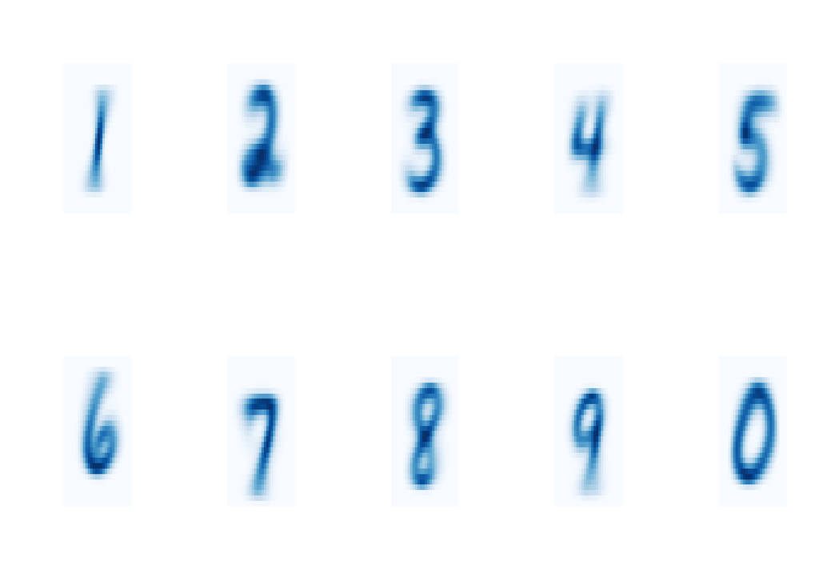

Those are the centroids. Now cluster test data on those centroids.

```r
set.seed(25)
clust<-kmeans(test,centroids, iter.max = 20)
clust$cluster<-clust$cluster%%10
t<-table(test[,1],clust$cluster)
df<-data.frame()
for (i in seq(1,10)){
  df<-rbind.data.frame(df,t[i,])
}
names(df)<-c('0','1','2','3','4','5','6','7','8','9')
df$`True Value`<-seq(0,9)
df<-df[,c(11,1,2,3,4,5,6,7,8,9,10)]
formattable(df, list(area(col = c(2,3,4,5,6,7,8,9,10,11) ) ~ color_tile("white", "blue")))
```

| True Value | 0 | 1 | 2 | 3 | 4 | 5 | 6 | 7 | 8 | 9 |
| --- | --- | --- | --- | --- | --- | --- | --- | --- | --- | --- |
| 0 | 800 | 3 | 0 | 54 | 7 | 286 | 40 | 1 | 4 | 0 |
| 1 | 0 | 1320 | 2 | 1 | 2 | 1 | 1 | 0 | 25 | 0 |
| 2 | 3 | 116 | 797 | 43 | 27 | 45 | 36 | 16 | 67 | 7 |
| 3 | 1 | 78 | 33 | 795 | 19 | 180 | 11 | 8 | 123 | 10 |
| 4 | 0 | 42 | 2 | 0 | 441 | 1 | 24 | 0 | 3 | 627 |
| 5 | 14 | 162 | 1 | 404 | 33 | 289 | 21 | 5 | 55 | 92 |
| 6 | 25 | 86 | 11 | 5 | 49 | 100 | 890 | 0 | 1 | 0 |
| 7 | 1 | 67 | 7 | 2 | 172 | 2 | 0 | 937 | 28 | 52 |
| 8 | 8 | 114 | 1 | 221 | 18 | 42 | 7 | 3 | 707 | 53 |
| 9 | 10 | 41 | 2 | 17 | 370 | 3 | 2 | 50 | 16 | 702 |

```r
numCorrect <- 0
for (i in seq(2,11)){
   numCorrect <- numCorrect + df[i-1,i]
}
accuracy <-numCorrect/sum(df)
print(accuracy)
```

```
## [1] 0.6374429
```

This looks worse than our previous result. But note that our last result was based on multiple versions of each digit, and here is based on only one version of each digit. Before when we only used one version of each digit some digits weren’t represented at all!

## Smarter Way Part 2

The data is partitioned into 10 subsections, each containing only one digit. Cluster in each subsection to find 4 main shapes within that digit.

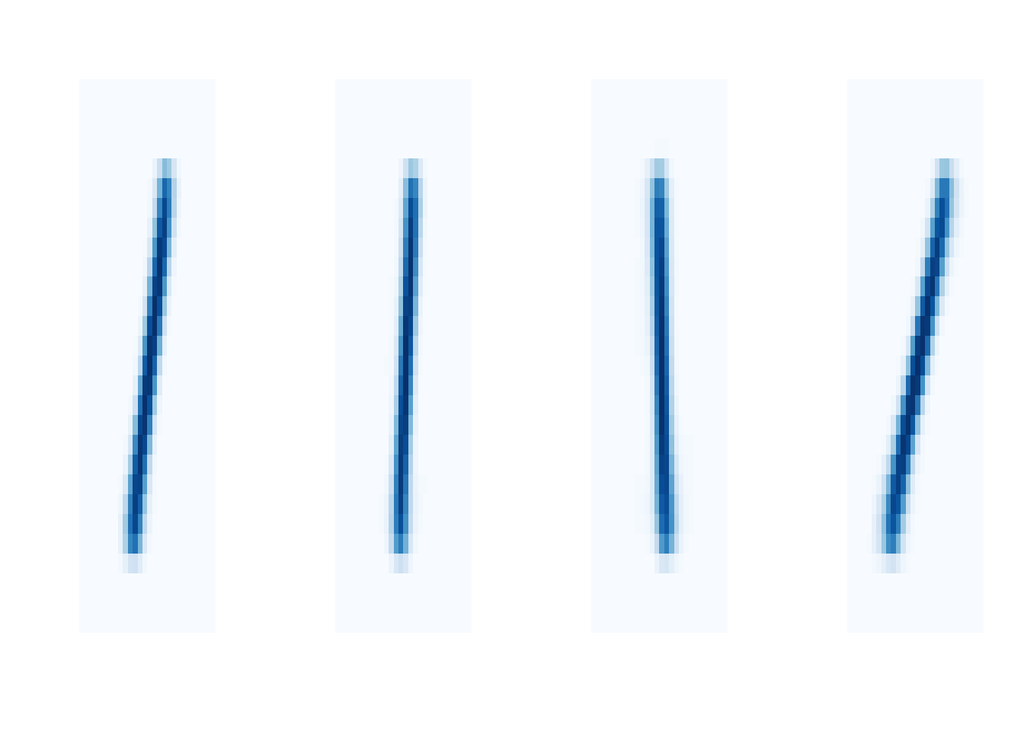

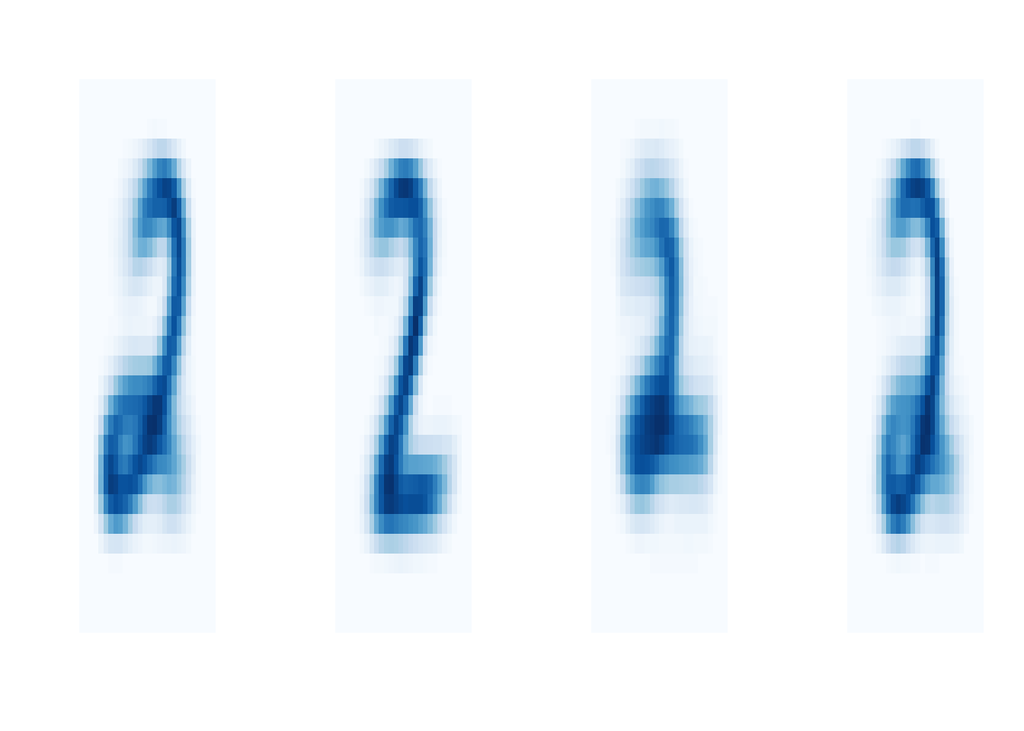

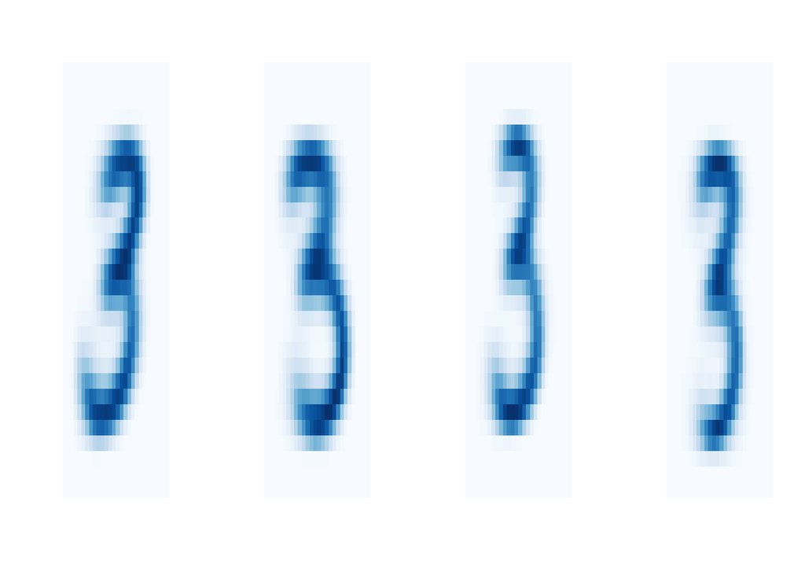

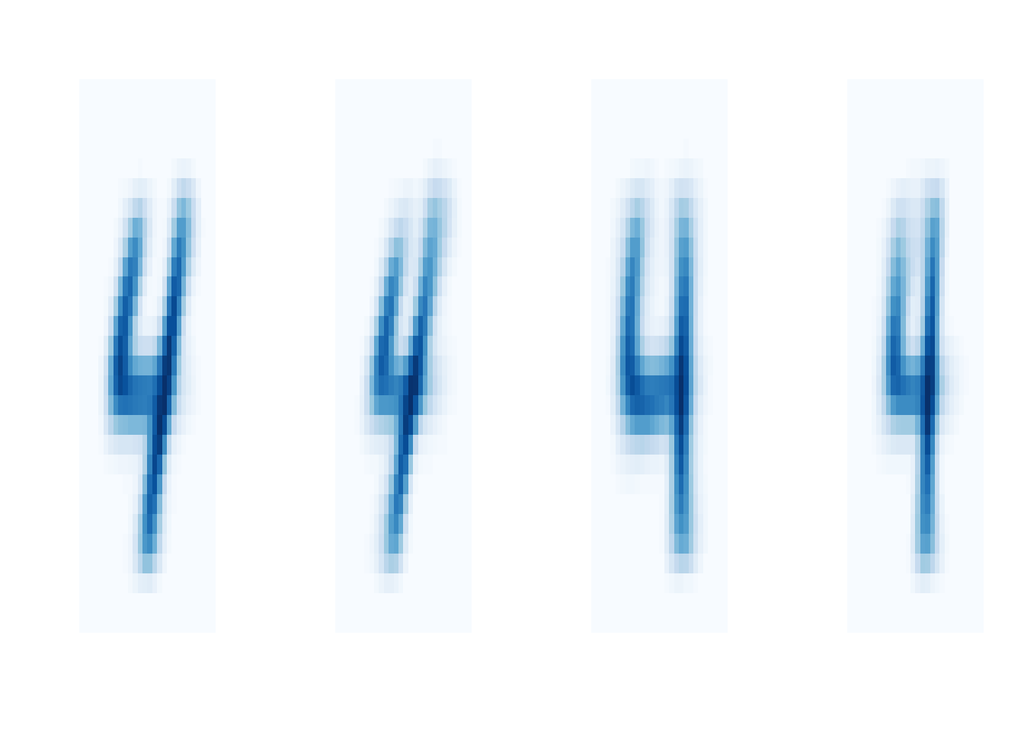

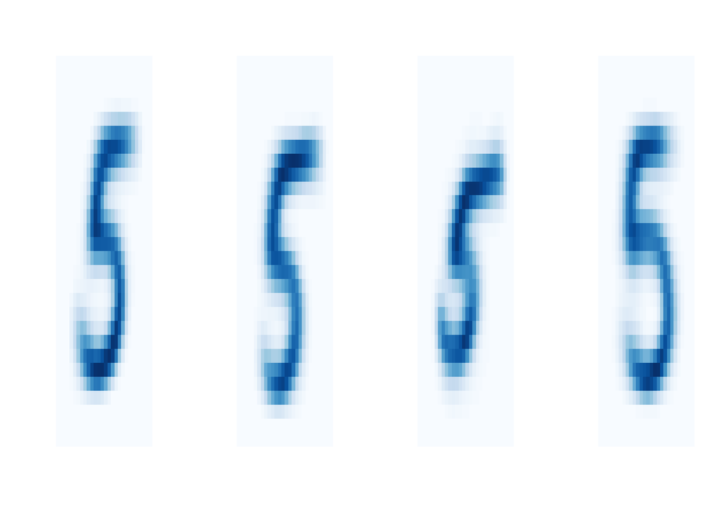

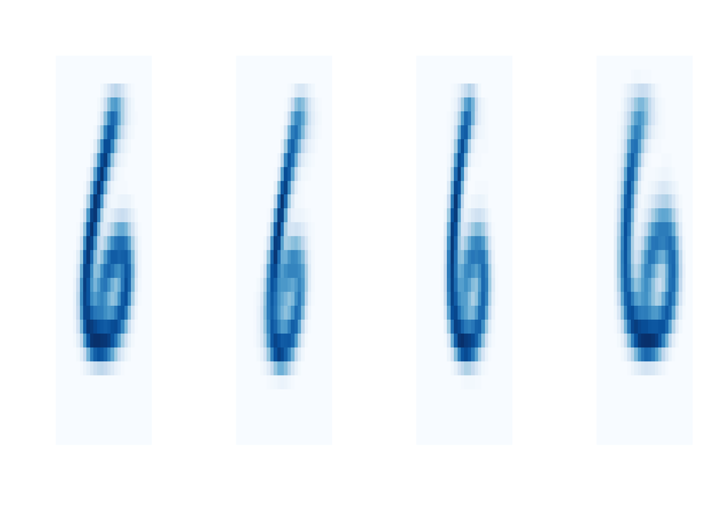

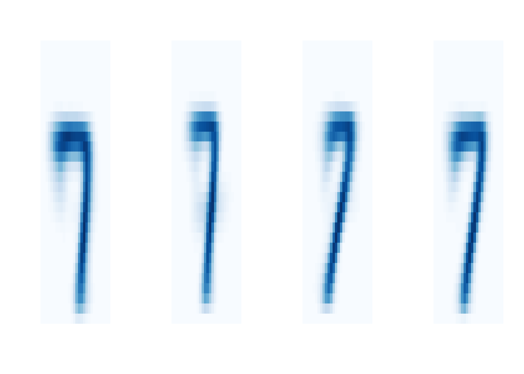

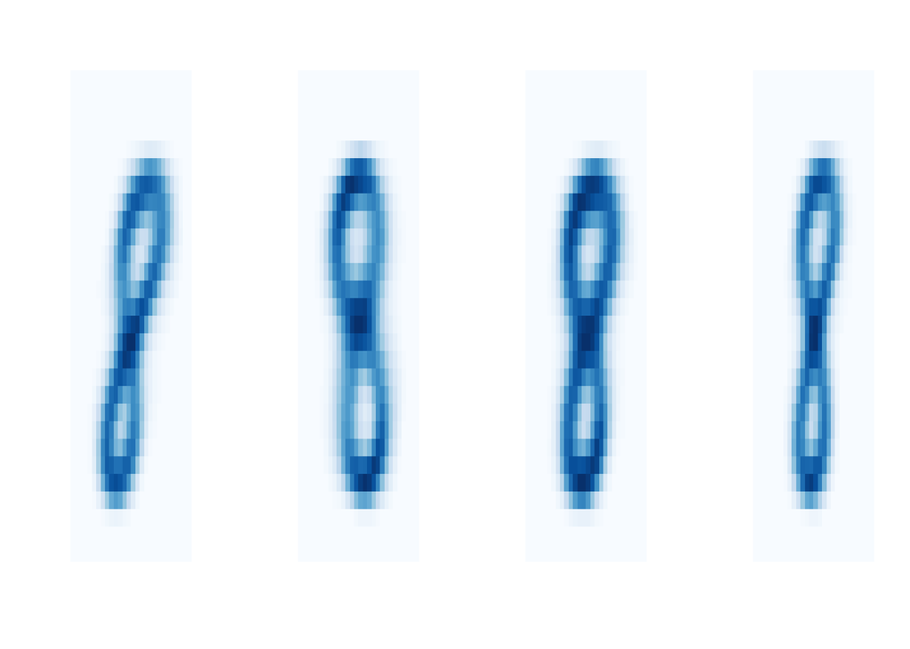

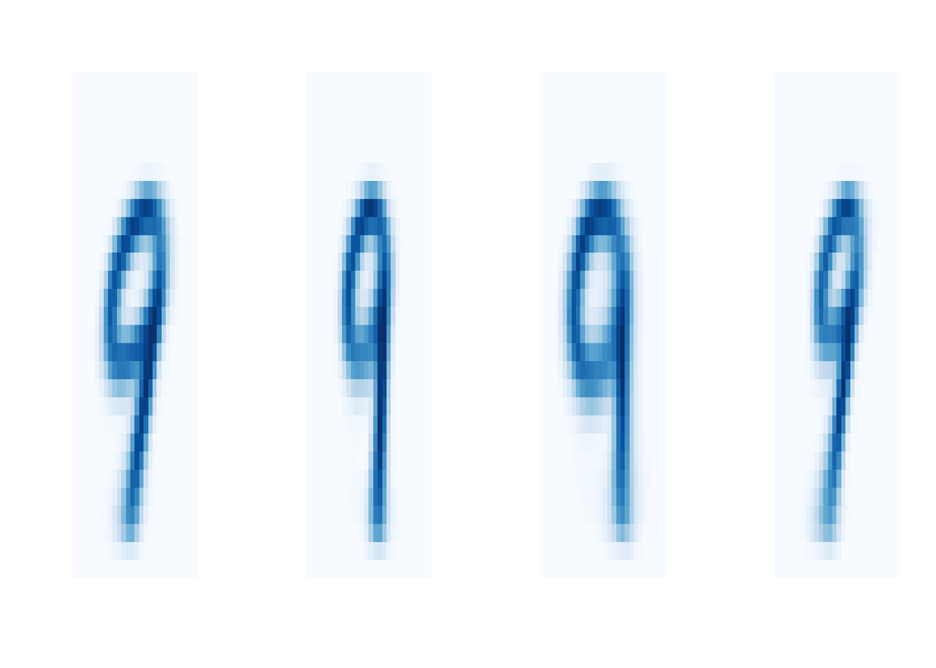

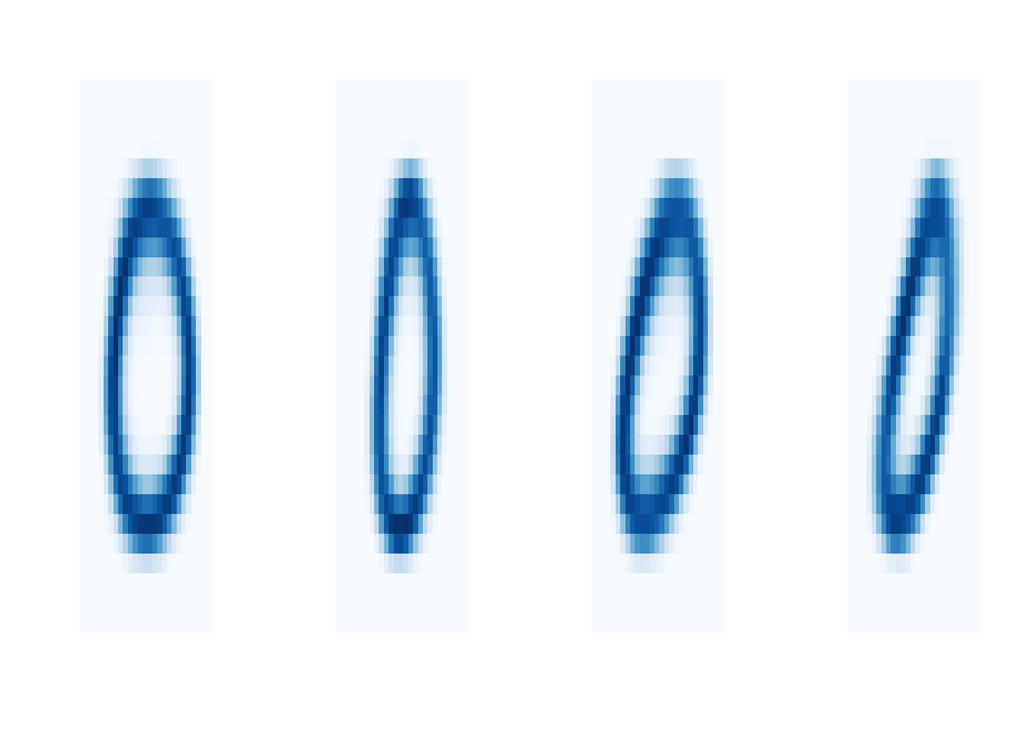

| True Value | 9 | 0 | 1 | 2 | 3 | 4 | 5 | 6 | 7 | 8 |
| --- | --- | --- | --- | --- | --- | --- | --- | --- | --- | --- |
| 0 | 1089 | 0 | 7 | 3 | 0 | 40 | 37 | 0 | 19 | 0 |
| 1 | 0 | 1333 | 2 | 0 | 1 | 2 | 3 | 0 | 11 | 0 |
| 2 | 15 | 23 | 1004 | 19 | 4 | 9 | 13 | 11 | 51 | 8 |
| 3 | 4 | 17 | 21 | 892 | 2 | 151 | 5 | 8 | 145 | 13 |
| 4 | 0 | 20 | 17 | 0 | 783 | 2 | 20 | 7 | 2 | 289 |
| 5 | 15 | 6 | 3 | 96 | 10 | 805 | 22 | 1 | 105 | 13 |
| 6 | 14 | 8 | 8 | 1 | 3 | 23 | 1101 | 0 | 8 | 1 |
| 7 | 1 | 32 | 13 | 0 | 44 | 4 | 0 | 967 | 4 | 203 |
| 8 | 7 | 28 | 7 | 64 | 5 | 85 | 4 | 10 | 936 | 28 |
| 9 | 6 | 8 | 7 | 8 | 333 | 7 | 1 | 80 | 16 | 747 |

## Accuracy

```
## [1] 0.8017435
```

## Why Stop Here?

Why stop at four clusters per digit? Let’s try ten clusters per digit.

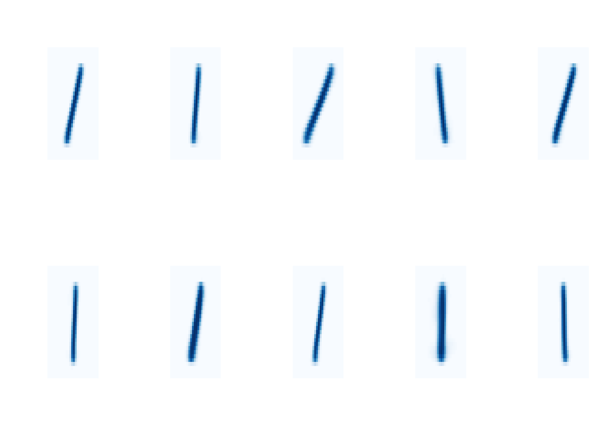

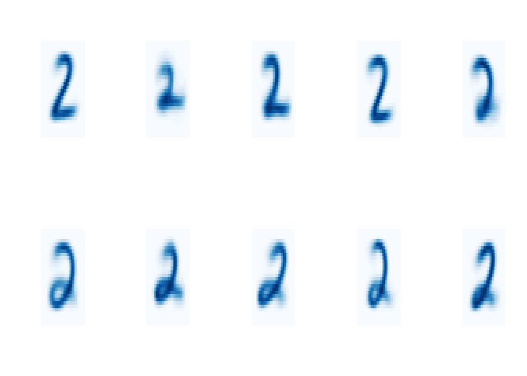

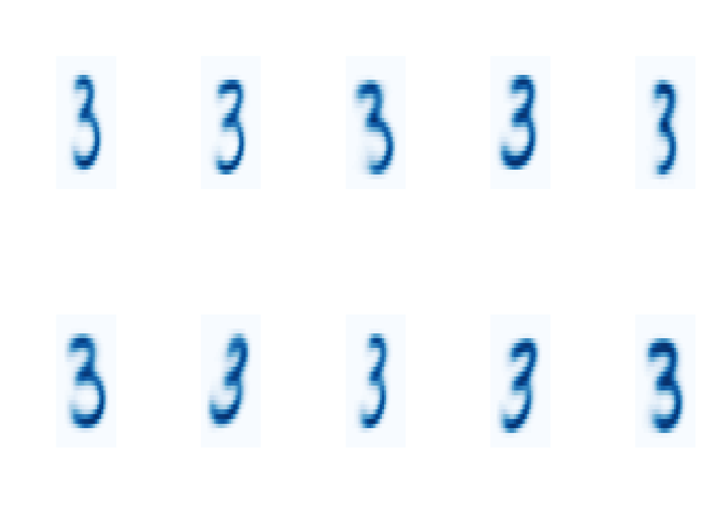

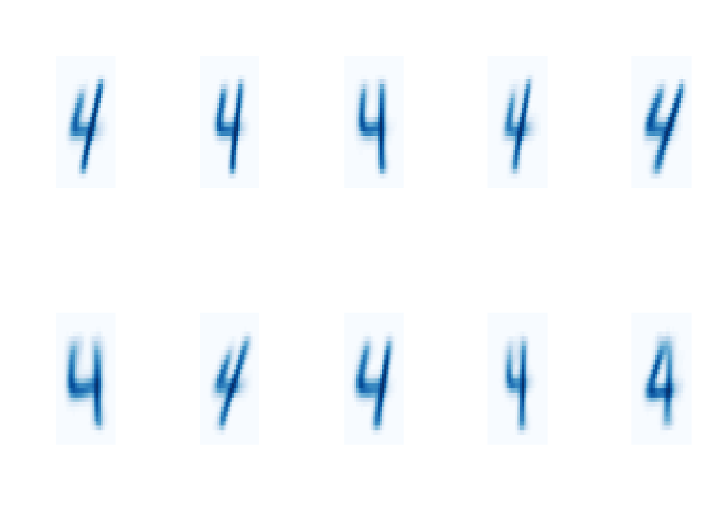

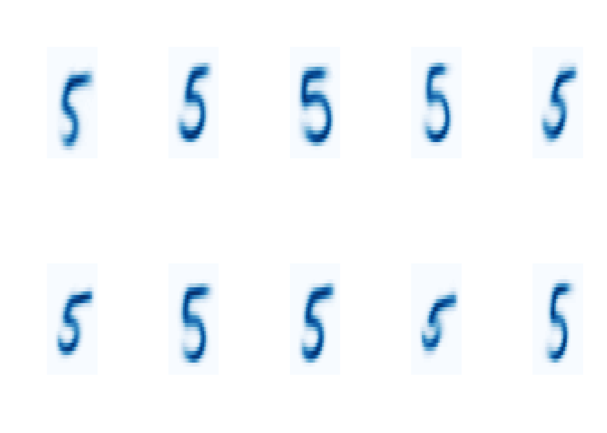

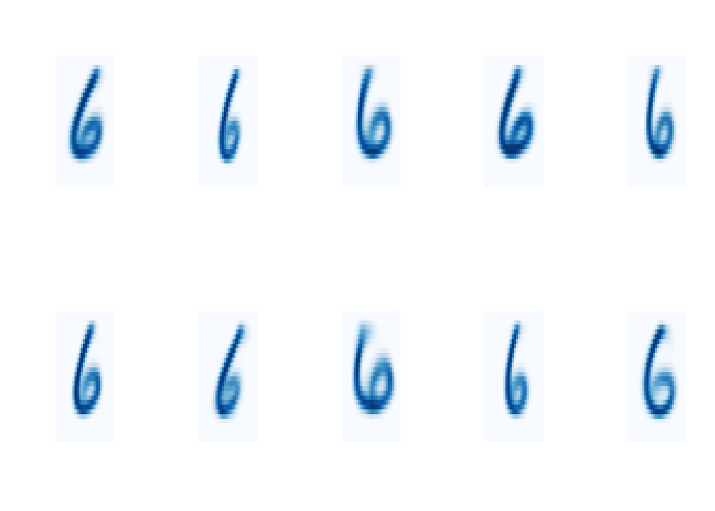

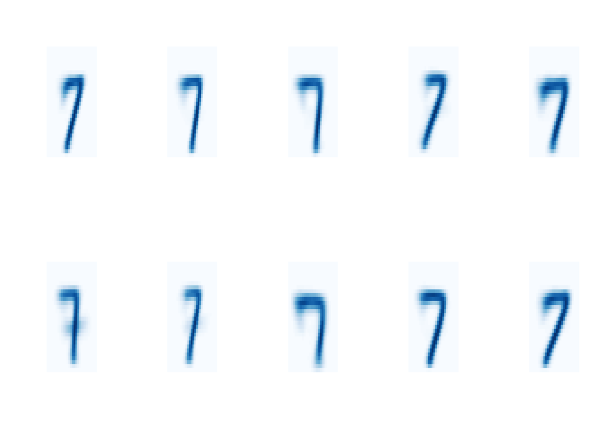

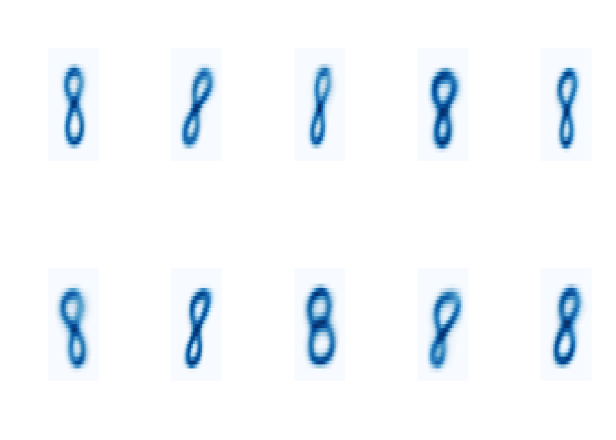

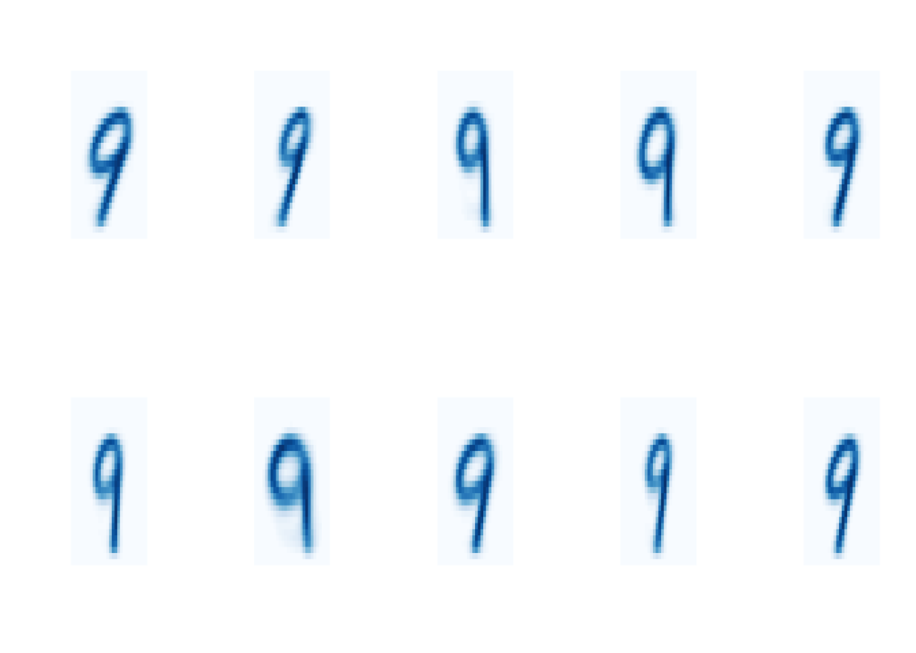

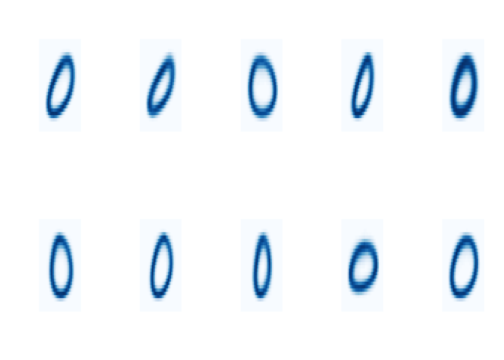

```r
clust3<-list()
for(i in seq(1,10)){
  clust3[[i]] <- kmeans(digits[[i]], 10, iter.max = 20)
}

par(mfrow=c(2,5))
for (j in seq(1,10)){
  for (i in seq(1,10)){
    showImage(clust3[[j]]$centers[i,], bluePalette)
  }
}
```

```r
centroids1<-data.frame()
for (i in seq(1,10)){
  centroids1<-rbind.data.frame(centroids1,clust3[[i]]$centers)
}


clust4<-kmeans(test, centroids1)
t<-table(test[,1],clust4$cluster)
#t
tt<-vector()
for (i in seq(1,10)){
  tmp<-rowSums(t[,(10*i-9):(10*i)])
  tt<-cbind(tt,tmp)
}
df<-data.frame()
for (i in seq(1,10)){
  df<-rbind.data.frame(df,tt[i,])
}
names(df)<-c('0','1','2','3','4','5','6','7','8','9')
df$`True Value`<-seq(0,9)
df<-df[,c(11,10,1,2,3,4,5,6,7,8,9)]
formattable(df, list(area(col = c(2,3,4,5,6,7,8,9,10,11) ) ~ color_tile("white", "blue")))
```

| True Value | 9 | 0 | 1 | 2 | 3 | 4 | 5 | 6 | 7 | 8 |
| --- | --- | --- | --- | --- | --- | --- | --- | --- | --- | --- |
| 0 | 1142 | 0 | 1 | 4 | 1 | 24 | 17 | 0 | 5 | 1 |
| 1 | 0 | 1334 | 3 | 4 | 2 | 3 | 0 | 0 | 4 | 2 |
| 2 | 13 | 10 | 1040 | 9 | 5 | 7 | 6 | 36 | 26 | 5 |
| 3 | 3 | 11 | 20 | 1076 | 5 | 70 | 5 | 12 | 45 | 11 |
| 4 | 0 | 14 | 9 | 0 | 877 | 1 | 13 | 1 | 2 | 223 |
| 5 | 6 | 3 | 3 | 52 | 9 | 953 | 13 | 3 | 23 | 11 |
| 6 | 8 | 4 | 7 | 0 | 3 | 19 | 1125 | 0 | 1 | 0 |
| 7 | 0 | 26 | 9 | 0 | 32 | 4 | 0 | 1112 | 4 | 81 |
| 8 | 2 | 18 | 3 | 51 | 9 | 65 | 2 | 5 | 1003 | 16 |
| 9 | 6 | 8 | 6 | 13 | 118 | 8 | 1 | 46 | 7 | 1000 |

## Accuracy

```
## [1] 0.8851806
```

## N - Clusters Per Digit

```r
results<-vector()
kClustersPerDigit<-function(k){
  clust3<-list()
  for(i in seq(1,10)){
    clust3[[i]] <- kmeans(digits[[i]], k, iter.max = 30)
    }

  centroids1<-data.frame()
  for (i in seq(1,10)){
    centroids1<-rbind.data.frame(centroids1,clust3[[i]]$centers)
  }


  clust4<-kmeans(test, centroids1)
  t<-table(test[,1],clust4$cluster)
  tt<-vector()
  for (i in seq(1,10)){
    tmp<-rowSums(t[,(k*i-(k-1)):(k*i)])
    tt<-cbind(tt,tmp)
  }
  df<-data.frame()
  for (i in seq(1,10)){
    df<-rbind.data.frame(df,tt[i,])
  }
  df$`True Value`<-seq(0,9)
  df<-df[,c(11,10,1,2,3,4,5,6,7,8,9)]
  names(df)<-c('True Label','0','1','2','3','4','5','6','7','8','9')

  numCorrect <- 0
  for (i in seq(2,11)){
   numCorrect <- numCorrect + df[i-1,i]
  }

  accuracy <-numCorrect/sum(df)
  print(accuracy)
  return(c(k,accuracy))
  }

library(parallel)
set.seed(25)
listToTry<-c(2,3,4,5,10,15,20,25,30,40,50,60,70,80,90,100)
mclapply(listToTry[1:15], kClustersPerDigit, mc.cores=4)
```

## Accuracy

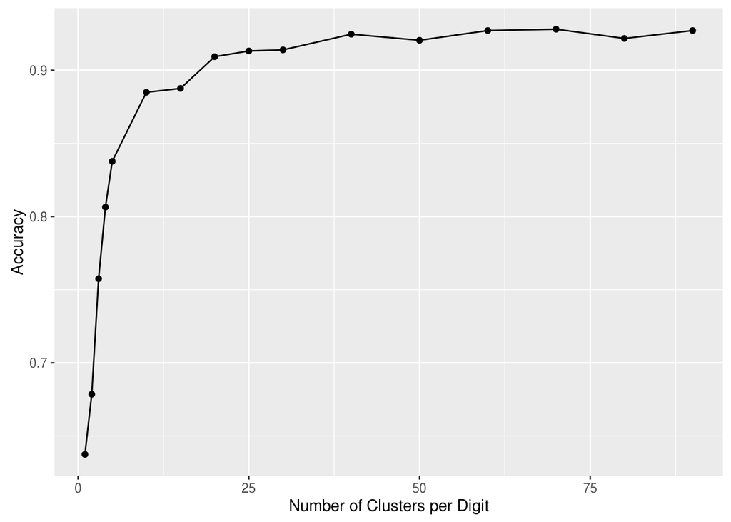